# Introduction to R

Caroline Hutchings

May 17, 2026

## Vectors

- Create a vector of numbers using assignment operator
- Create a vector of strings

```r
week <- c('Monday', 'Tuesday', 'Wednesday', 'Thursday', 'Friday')
```

- Create a vector with a range of numbers

```r
seq(1,10)
```

```
##  [1]  1  2  3  4  5  6  7  8  9 10
```

- Length of vector

```r
length(week)
```

```
## [1] 5
```

## Working with Vectors

- Create a named vector

```r
temps <- c('Mon'=88, 'Tue'=93, 'Wed'=95, 'Thu'=91, 'Fri'=86)
temps
```

```
## Mon Tue Wed Thu Fri
##  88  93  95  91  86
```

- Retrieve names of vector

```r
names(temps)
```

```
## [1] "Mon" "Tue" "Wed" "Thu" "Fri"
```

- Add values to a vector

```r
temps <- append(temps, c('Sa'=81, 'Su'=78))
temps
```

```
## Mon Tue Wed Thu Fri  Sa  Su
##  88  93  95  91  86  81  78
```

## Indexing

- Identify item at specific index

```r
week[1]
```

```
## [1] "Monday"
```

- All items except at specified index

```r
week[-2]
```

```
## [1] "Monday"    "Wednesday" "Thursday"  "Friday"
```

- All items in vector of indexes

```r
week[c(1,3,5)]
```

```
## [1] "Monday"    "Wednesday" "Friday"
```

## Working with Vector Operators

- Relational Operators

```r
temps == 81
```

```
##   Mon   Tue   Wed   Thu   Fri    Sa    Su
## FALSE FALSE FALSE FALSE FALSE  TRUE FALSE
```

```r
temps > 88
```

```
##   Mon   Tue   Wed   Thu   Fri    Sa    Su
## FALSE  TRUE  TRUE  TRUE FALSE FALSE FALSE
```

```r
temps != 81
```

```
##   Mon   Tue   Wed   Thu   Fri    Sa    Su
##  TRUE  TRUE  TRUE  TRUE  TRUE FALSE  TRUE
```

- Write code to shorten the names of temps

```r
names(temps) <- c('M', 'T', 'W', 'Th', 'F')
temps
```

```
##    M    T    W   Th    F <NA> <NA>
##   88   93   95   91   86   81   78
```

- Write code to select temperature of Friday

```r
temps['F']
```

```
##  F
## 86
```

```r
temps[5]
```

```
##  F
## 86
```

## Dataframes

- Create a dataframe from vectors

```r
months <- c('Jan', 'Feb', 'Mar', 'Apr', 'May', 'Jun', 'Jul', 'Aug', 'Sep', 'Oct', 'Nov', 'Dec')
num_days <- c(31,28,31,30,31,30,31,31,30,31,30,31)
seasons <- c('W', 'W', 'Sp', 'Sp', 'Sp', 'Su', 'Su', 'Su', 'F', 'F', 'F', 'W')
calendar_df <- data.frame(Month = months, NumDays = num_days, Season=seasons)
calendar_df
```

```
##    Month NumDays Season
## 1    Jan      31      W
## 2    Feb      28      W
## 3    Mar      31     Sp
## 4    Apr      30     Sp
## 5    May      31     Sp
## 6    Jun      30     Su
## 7    Jul      31     Su
## 8    Aug      31     Su
## 9    Sep      30      F
## 10   Oct      31      F
## 11   Nov      30      F
## 12   Dec      31      W
```

## Dataframe Manipulations

- Add rows to a dataframe

```r
calendar_df <- rbind(calendar_df, list('NewJan', 31, 'Bonus'), list('NewFeb', 29, 'Bonus'))
calendar_df
```

```
##     Month NumDays Season
## 1     Jan      31      W
## 2     Feb      28      W
## 3     Mar      31     Sp
## 4     Apr      30     Sp
## 5     May      31     Sp
## 6     Jun      30     Su
## 7     Jul      31     Su
## 8     Aug      31     Su
## 9     Sep      30      F
## 10    Oct      31      F
## 11    Nov      30      F
## 12    Dec      31      W
## 13 NewJan      31  Bonus
## 14 NewFeb      29  Bonus
```

- Add columns to a dataframe

```r
avg_temp <- c(52.3, 56.1, 62, 68.9, 75.9, 80.7, 81.9, 82.7, 78.5, 70.7, 61.1, 54.3, 53.4, 0)
calendar_df <- cbind(calendar_df, AvgTemp = avg_temp)
calendar_df
```

```
##     Month NumDays Season AvgTemp
## 1     Jan      31      W    52.3
## 2     Feb      28      W    56.1
## 3     Mar      31     Sp    62.0
## 4     Apr      30     Sp    68.9
## 5     May      31     Sp    75.9
## 6     Jun      30     Su    80.7
## 7     Jul      31     Su    81.9
## 8     Aug      31     Su    82.7
## 9     Sep      30      F    78.5
## 10    Oct      31      F    70.7
## 11    Nov      30      F    61.1
## 12    Dec      31      W    54.3
## 13 NewJan      31  Bonus    53.4
## 14 NewFeb      29  Bonus     0.0
```

## Logical Operators

- Find Months with 30 days that are warmer than 70 degrees.
- Find Months that have a temperature lesss than 70 degrees or are summer months.

```r
calendar_df$AvgTemp >=70 & calendar_df$NumDays==30 #AND
```

```
##  [1] FALSE FALSE FALSE FALSE FALSE  TRUE FALSE FALSE  TRUE FALSE FALSE FALSE
## [13] FALSE FALSE
```

```r
calendar_df$AvgTemp <=70 | calendar_df$Season=='Su'
```

```
##  [1]  TRUE  TRUE  TRUE  TRUE FALSE  TRUE  TRUE  TRUE FALSE FALSE  TRUE  TRUE
## [13]  TRUE  TRUE
```

## Dataframe Application

- Find proportion of months with 31 days that are above 70 degrees.
- Find proportion of months that have less than 31 days or are above 70 degrees.
- Add a code chunck and then write code to answer the questions.

### Solution

```r
mean(calendar_df$AvgTemp >70 & calendar_df$NumDays==31)
```

```
## [1] 0.2857143
```

```r
mean(calendar_df$AvgTemp >70 | calendar_df$NumDays<31)
```

```
## [1] 0.7142857
```

```r
library(tidyverse)
#convert a dataframe to a tibble
calendar_tibble <- as_tibble(calendar_df)
is_tibble(calendar_tibble)
```

```
## [1] TRUE
```

```r
is_tibble(calendar_df)
```

```
## [1] FALSE
```

## Load Data Set

- Load data using Kaggle CLI

```r
library(tidyverse)

system("kaggle --version")
```

```
## [1] 0
```

```r
# If Kaggle is not loaded that use pip install kaggle in command prompt

# Download dataset using Kaggle CLI
system("kaggle datasets download -d zeeshier/student-admission-records")
```

```
## [1] 0
```

```r
# Unzip dataset
unzip("student-admission-records.zip")

# Import into R
student_admission <- read_csv("student_admission_record_dirty.csv")
# Check if it's a tibble
is_tibble(student_admission)
```

```
## [1] TRUE
```

## View Data in Spreadsheet Format

- View data in interactive window

```r
View(student_admission)
```

## Missing Data

- Check for missing data

```r
#count of rows that have missing name
sum(is.na(student_admission$Name))
```

```
## [1] 10
```

```r
#count of NA values for all columns
student_admission %>%
  apply(MARGIN = 2, function(col) sum(is.na(col)))
```

```
##                   Name                    Age                 Gender
##                     10                     10                     10
##   Admission Test Score High School Percentage                   City
##                     11                     11                     10
##       Admission Status
##                     10
```

```r
#count of rows with one or more missing values
sum(!complete.cases(student_admission))
```

```
## [1] 57
```

```r
#drop rows with one or more missing values
student_admission_dropna <- student_admission %>%
  filter(complete.cases(student_admission))
nrow(student_admission_dropna)
```

```
## [1] 100
```

- Replace missing values with ‘Unknown’

```r
#replace Name with 'Unknown'
student_admission_replace_na <- student_admission %>%
  mutate(Name = replace_na(Name, 'Unknown'))

nrow(student_admission_replace_na)
```

```
## [1] 157
```

```r
sum(!complete.cases(student_admission_replace_na))
```

```
## [1] 51
```

```r
#replace Name and Admission Status with 'Unknown'
student_admission_replace_na_two <- student_admission %>%
  mutate(across(c(Name, `Admission Status`),~ replace_na(.,'Unknown')))

nrow(student_admission_replace_na_two)
```

```
## [1] 157
```

```r
sum(!complete.cases(student_admission_replace_na_two))
```

```
## [1] 47
```

## Student Admission Data Project

### Examine Count of Unique Values

```r
#lapply is list apply and apply is column/matrix apply
apply(X=student_admission, MARGIN = 2, FUN = unique) %>% #MARGIN=2 means column fun=function
  lapply(FUN = length) %>% str()
```

```
## List of 7
##  $ Name                  : int 65
##  $ Age                   : int 10
##  $ Gender                : int 3
##  $ Admission Test Score  : int 50
##  $ High School Percentage: int 130
##  $ City                  : int 8
##  $ Admission Status      : int 3
```

### Examine Admission Status

```r
unique(student_admission$`Admission Status`)
```

```
## [1] "Rejected" NA         "Accepted"
```

### Select and Rename Columns

```r
student_admission <- student_admission %>%
  select(Name, Age, Gender, `High School Percentage`, `Admission Test Score`, `Admission Status`, City)

names(student_admission) <- c("Name", "Age", "Gender", "HS_Percentage", "TestScore", "Admit", "City")
```

### Change Data Types

```r
student_admission <- student_admission %>%
  mutate(
    Age = as.numeric(Age),
    HS_Percentage = as.numeric(HS_Percentage),
    TestScore = as.numeric(TestScore),
    Admit = ifelse(Admit == "Accepted", TRUE, FALSE)
  )
```

### Handling Missing Values

```r
student_admission <- student_admission %>%
  mutate(
    Name = replace_na(Name, "Unknown"),
    HS_Percentage = replace_na(HS_Percentage, mean(HS_Percentage, na.rm = TRUE)),
    TestScore = replace_na(TestScore, mean(TestScore, na.rm = TRUE))
  )
```

### Create Performance Category and Add to Tibble

```r
student_admission <- student_admission %>%
  mutate(
    Performance = case_when(
      HS_Percentage >= 85 ~ "High",
      HS_Percentage >= 70 ~ "Medium",
      TRUE ~ "Low"
    )
  )

View(student_admission)
```

### Create Combined Score

```r
student_admission <- student_admission %>%
  mutate(
    CombinedScore = HS_Percentage + TestScore
  )

View(student_admission)
```

### Group- Level Summary

```r
student_admission <- student_admission %>%
  group_by(City) %>%
  mutate(
    AvgCombinedScoreCity = mean(CombinedScore, na.rm = TRUE),
    AdmitRateCity = mean(Admit, na.rm = TRUE),
    CountCity = n()
  )
View(student_admission)
```

### City Summary

```r
city_summary <- student_admission %>%
  group_by(City) %>%
  summarize(
    MeanPercent = mean(HS_Percentage, na.rm = TRUE),
    MeanTest = mean(TestScore, na.rm = TRUE),
    AdmitRate = mean(Admit, na.rm = TRUE),
    Count = n()
  )

city_summary
```

```
## # A tibble: 8 × 5
##   City       MeanPercent MeanTest AdmitRate Count
##   <chr>            <dbl>    <dbl>     <dbl> <int>
## 1 Islamabad         74.6     82.6     0.438    17
## 2 Karachi           78.1     79.0     0.385    28
## 3 Lahore            76.5     77.4     0.75     17
## 4 Multan            84.6     75.7     0.476    21
## 5 Peshawar          79.3     78.2     0.389    18
## 6 Quetta            72.4     75.2     0.448    30
## 7 Rawalpindi        65.2     72.8     0.571    16
## 8 <NA>              70.9     84.2     0.571    10
```

### Admission Rate per Performance Group

```r
admit_pct <- student_admission %>%
  group_by(Performance) %>%
  summarize(
    Admitted = sum(Admit, na.rm = TRUE),
    Total = n()
  ) %>%
  mutate(
    AdmitPct = Admitted / Total
  )

admit_pct
```

```
## # A tibble: 3 × 4
##   Performance Admitted Total AdmitPct
##   <chr>          <int> <int>    <dbl>
## 1 High              23    48    0.479
## 2 Low               20    54    0.370
## 3 Medium            28    55    0.509
```

### Graph Admission Rate by Performance

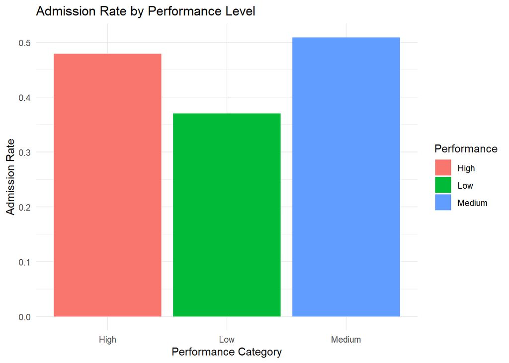

```r
ggplot(admit_pct, aes(x = Performance, y = AdmitPct, fill = Performance)) +
  geom_col() +
  labs(
    title = "Admission Rate by Performance Level",
    x = "Performance Category",
    y = "Admission Rate"
  ) +
  theme_minimal()
```

### Interactive Graph using Plotly

```r
#install.packages("plotly")
library(plotly)
p <- ggplot(admit_pct, aes(x = Performance, y = AdmitPct, fill = Performance)) +
  geom_col()

ggplotly(p)
```

[interactive chart not shown]